# Lab 01: Urbana Weather

Author

Afnan Dzaharudin

Published

January 29, 2024

# Lab 01: Urbana Weather

## Introduction

Every other Saturday during the Spring and Fall semesters, my partner and I wake up earlier in the morning to visit the [Urbana’s Farmer’s Market](https://urbanamarket.org)! It’s a lovely place where local vendors gather to sell their produce and crafts. My partner loves getting a croissant loaf from one of the bakers, while I often get myself a batch of uncommon ingredients like kohlrabi, chestnut mushrooms, and lion’s mane mushrooms. One winter, we visited the area to find that the Farmer’s Market was not where they usually were. From a stroll in the nearby Lincoln Square mall, we found out that they moved indoors for the cold season - fair enough!

As it turns out, it’s a really good idea to move the Market indoors when it gets colder, both for the sake of the vendors (who would be there from morning till noon), as well as for the customers (who would want to browse leisurely, preferably not while shivering). But doing so on a whim would be bad for vendors, as some would likely miss the memo and set themselves up outdoors that week. Conversely, announcing the move to indoors *too early* would be a waste of good weather to walk in! Therefore, it would be useful to have a tool that could help predict the temperature of a given future date, so that the move-in decision can be made in an informed and timely manner.

This report describes my process of developing a [K-Nearest Neighbors regressor](https://scikit-learn.org/stable/modules/neighbors.html#regression) that utilizes past temperature data in Urbana to predict future temperatures, given a year and day-of-the-year.

## Methods

In this report, we first assess the data being handled, by showing a yearly and monthly summary table of the mean and standard deviation of the minimum temperatures, as well as by visualizing how these temperatures change over time. After understanding the data, we then fit the validation-train data to a variety of `KNeighborsRegressor` models, each with a different set of distance metrics and $k$ values. Finally, we report the root mean squared errors from each models’ predictions on the validation data, and also include a visualization in hopes to better show how each model performed.

```python
# imports
import pandas as pd
import numpy as np
import seaborn as sns
import matplotlib.pyplot as plt

sns.set_style("whitegrid", {
        'grid.linestyle': "--",
        'axes.spines.top': False,
        'axes.spines.right': False,
        'axes.edgecolor': 'black',
        'xtick.bottom': True,
        'ytick.left': True
    })

from sklearn.neighbors import KNeighborsRegressor
from sklearn.metrics import root_mean_squared_error

import datetime
from calendar import month_name
```

### Data

```python
# load data
weather_train = pd.read_csv(
    "https://cs307.org/lab-01/data/weather-train.csv",
    index_col="date",
    parse_dates=True
)
weather_vtrain = pd.read_csv(
    "https://cs307.org/lab-01/data/weather-vtrain.csv",
    index_col="date",
    parse_dates=True
)
weather_validation = pd.read_csv(
    "https://cs307.org/lab-01/data/weather-validation.csv",
    index_col="date",
    parse_dates=True
)
```

To create our model, we use data queried from the [Historical Weather API](https://open-meteo.com/en/docs/historical-weather-api/) by [Open Meteo](https://open-meteo.com/), a free and open-source API for weather forecasts and historical weather data.

By querying the Historical Weather API with the approximate coordinates of Lincoln Square, we get temperature data for the area that is almost precisely where the Urbana Farmer’s Market operates. Our dataset has the following variables:

| Variable name(s) | Description |
| --- | --- |
| `date` | Formated as `yyyy-mm-dd`, it is the date when that row’s data was reported |
| `temperature_2m_min` | The minimum temperature, 2 meters above the ground, in Celcius |
| `year`, `month`, `day` | Isolated parts of the `date` variable |
| `day_of_year` | A number representing the day in the year, ranging from 1 to 365 (or 366 on a leap year) |

Recall that we want to know future temperatures in order to know when to move the Farmer’s Market indoors. It would be safest to make this decision on *minimum temperatures*, which would represent the worst-case temperature on a given day, therefore our model will predict minimum temperatures given its inputs.

```python
# summary statistics
## yearly count, mean, and standard deviation
table_yearly = weather_train[["year", "temperature_2m_min"]].groupby(["year"]).agg(["count", "mean", "std"])
table_yearly
```

| year | temperature_2m_min count | temperature_2m_min mean | temperature_2m_min std |
| --- | --- | --- | --- |
| 2016 | 366 | 8.793391 | 10.274506 |
| 2017 | 365 | 8.399644 | 9.692305 |
| 2018 | 365 | 7.591014 | 11.369452 |
| 2019 | 365 | 7.229781 | 10.882260 |
| 2020 | 366 | 7.684612 | 9.383593 |
| 2021 | 365 | 8.119370 | 10.388489 |
| 2022 | 365 | 7.010192 | 11.028170 |

```python
## monthly mean and standard deviation
table_monthly = weather_train[["month", "temperature_2m_min"]].groupby(["month"]).agg(["mean", "std"])
table_monthly
```

| month | temperature_2m_min mean | temperature_2m_min std |
| --- | --- | --- |
| 1 | -5.416767 | 6.547430 |
| 2 | -4.380614 | 6.746122 |
| 3 | 1.522173 | 5.595675 |
| 4 | 5.925214 | 5.659612 |
| 5 | 12.639454 | 5.234890 |
| 6 | 18.211405 | 3.540279 |
| 7 | 19.998210 | 2.627939 |
| 8 | 19.088071 | 2.874603 |
| 9 | 16.571643 | 3.988397 |
| 10 | 9.756274 | 5.775242 |
| 11 | 1.888310 | 5.663248 |
| 12 | -2.514694 | 5.680539 |

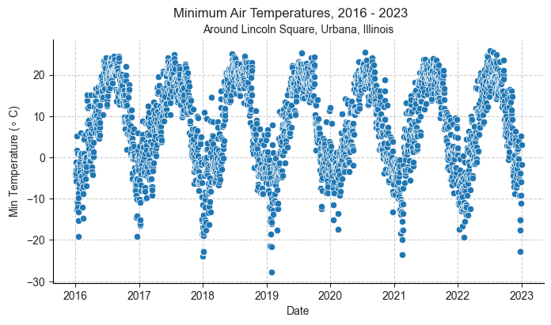

```python
# visualizations

## yearly plot
### elongate horizontally
plt.figure(figsize=(8, 4))

### scatterplot
sns.scatterplot(weather_train, x="date", y="temperature_2m_min")

### labels
plt.suptitle("Minimum Air Temperatures, 2016 - 2023")
plt.title("Around Lincoln Square, Urbana, Illinois", fontsize=10)
plt.ylabel("Min Temperature ($\circ$ C)")
plt.xlabel("Date")

plt.show()
```

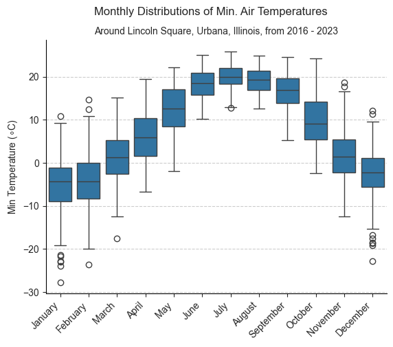

```python
## monthly plot
sns.boxplot(weather_train, x="month", y="temperature_2m_min")

plt.suptitle("Monthly Distributions of Min. Air Temperatures")
plt.title("Around Lincoln Square, Urbana, Illinois, from 2016 - 2023", fontsize=10)
plt.xlabel("") # :)
plt.xticks(np.arange(0, 12), [month_name[i] for i in range(1, 13)], rotation=45, ha="right")
plt.ylabel("Min Temperature ($\circ$C)")
plt.show()
```

### Models

```python
# process data for ML
X_vtrain = weather_vtrain[["year", "day_of_year"]]
y_vtrain = weather_vtrain["temperature_2m_min"]

X_validation = weather_validation[["year", "day_of_year"]]
y_validation = weather_validation["temperature_2m_min"]
```

```python
# train models
k_vals = [5, 20, 50]
methods = ["euclidean", "manhattan"]
knn_clfs = []

for k in k_vals:
    for m in methods:
        clf = KNeighborsRegressor(n_neighbors=k, metric=m)
        clf.fit(X_vtrain, y_vtrain)
        knn_clfs.append(clf)
```

We will focus solely on attempting to use K-Nearest Neighbors. Even so, we still have a lot of options within that one model.

For our report, we show a total of six models with the following hyperparameters:

1. Euclidean distance, with:
   - $k = 5$ neighbors
   - $k = 20$ neighbors
   - $k = 50$ neighbors
2. [Manhattan](https://simple.wikipedia.org/wiki/Manhattan_distance) distance, with:
   - $k = 5$ neighbors
   - $k = 20$ neighbors
   - $k = 50$ neighbors.

## Results

```python
# create a long-format dataframe of predicted values
# this took me ages to figure out a clean solution for
df_pred = pd.DataFrame()

for i in range(len(knn_clfs)):
    metric = knn_clfs[i].get_params()['metric']
    k = knn_clfs[i].get_params()['n_neighbors']

    y_pred = knn_clfs[i].predict(X_validation)
    result = pd.DataFrame({"n_neighbors": k, "metric": metric, "value": y_pred}, index=y_validation.index)
    df_pred = pd.concat([df_pred, result])
```

We present our results two ways:

1. We calculate the **root mean-squared error**, a numerical measure of performance for each of our six KNN models. Our models, fitted on *validation-train* data, is made to predict the min. temperatures of our *validation* data, and these predictions are compared with the true min. temperatures from that validation set.
2. We create a **visualization**: a lineplot for each models’ predicted values, with the true validation set values as a scatterplot in the background. This lets us see how the models’ predictions vary over a fixed set of time.
   - Our plots are limited from August 2021 to February 2022. Plotting the full available date-range severely hindered the readability of the lineplots.

```python
# report model metrics
# python doesn't have a good way to chain method calls :(
table_rmse = df_pred.groupby(["metric", "n_neighbors"]) \
    .agg(lambda x: root_mean_squared_error(y_validation, x)) \
    .rename({"value":"rmse"}, axis=1)
table_rmse
```

| metric | n_neighbors | rmse |
| --- | --- | --- |
| euclidean | 5 | 5.481194 |
|  | 20 | 5.030581 |
|  | 50 | 5.000248 |
| manhattan | 5 | 5.381206 |
|  | 20 | 5.044338 |
|  | 50 | 4.997879 |

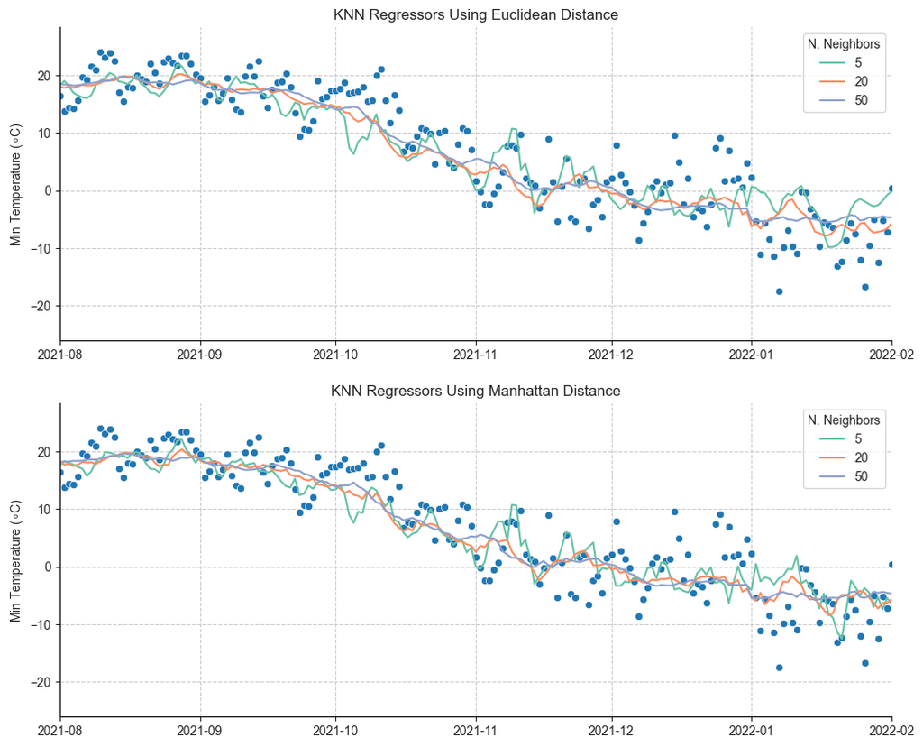

```python
# one plot for each metric
fig, axs = plt.subplots(2, 1, figsize=(12,10))

for i in range(2):
    metric = methods[i]

    # plot a scatterplot of the true values
    sns.scatterplot(x=y_validation.index, y=y_validation, ax=axs[i])

    # plot the estimated values as a line
    sns.lineplot(df_pred[df_pred["metric"] == metric],
                 x="date", y="value", hue="n_neighbors",
                 ax=axs[i], palette="Set2")

    # labels
    axs[i].set_title("KNN Regressors Using {} Distance".format(metric.capitalize()))
    axs[i].set_ylabel("Min Temperature ($\circ$C)")
    axs[i].set_xlabel("")
    axs[i].get_legend().set_title("N. Neighbors")

    # use a limited date range for better plot readability
    axs[i].set_xlim(datetime.date(2021, 8, 1), datetime.date(2022, 2, 1))

plt.show()
```

## Discussion

Let’s talk about the data first. We can see from the year-to-year plots that the minimum temperature in Urbana oscillates from warm to cold in a rather consistent pattern, which is expected as Illinois experiences the four seasons. That being said, the fact that we have this pattern means we can’t go for something simpler like linear regression, so K-Nearest Neighbors seems relatively more fitting.

Actually, *does* K-Nearest Neighbors make sense if we’re predicting based on the year and day-of-the-year? The answer I’ve come to is it *maybe* does, but we have to be careful to make sure the model wants to do what we expect it to.

For example, say we wanted to predict the minimum temperature on July 13, 2024. We would probably want to predict this based on minimum temperatures around July, and maybe only from the past one or two years. Would a distance metric select these “neighbors” correctly? The visualization of the results from the above lean towards ‘yes,’ but it would be a worthwhile endeavor to take a closer look at the algorithm and really see which neighboring points are chosen for a given input.

Additionally, meteorology isn’t my specialty, so there may be even more said for or against KNN here that I wouldn’t know about.

The validity of our model also assumes the Historical Data API is accurate about its reported temperatures. It should be noted that the API also performs its own predictions to fill in gaps, so we should be wary about exactly how much of our data are just guesses. That being said, the model is also said to be more accurate about weather conditions at smaller scales, so maybe pinpointing on a location as exact as Lincoln Square might be in our favor.

Finally, let’s talk about the modelling. Generally, our models achieve an RMSE of around $4.9$ to $5.4 ^\circ C$, which I feel isn’t the best; being off by 5 degrees can be a difference between pleasant and chilly. Of the six models we tried, KNN with Manhattan distance and $k=50$ neighbors achieved the lowest RMSE.

I would *not* say that Manhattan is better than Euclidean, as for a given $k$ value, the RMSE values for either distance metrics barely differ.

As for $k$ values, I personally think that higher $k$ values are better in this case. Based on the visualization just above, the $k=5$ and $k=20$ models for either distance metric produces a line that ‘wiggles’ a little too much for my liking; it seems to succumb too much to the local outliers, while the $k=50$ models follow the oscillating trend more smoothly.

### Conclusion

Using various K-Nearest Neighbors regressors, we have produced a set of models that attempt to predict the minimum temperature around Lincoln Square in Urbana, Ilinois, based on the year and day of that year. If a model *had* to be chosen, I’d choose theregressor using Manhattan distance and $k=50$ neighbors.

Still, I would hestitate to pick a model from this report for several reasons:

- An RMSE of around $5^\circ C$ is likely not ideal, as being incorrect about the weather by $5^\circ C$ on average can be a big difference between comfortable and un-ideal weather.
- More work should be done to evaluate whether it is ideal to predict based on *distance* between years and days-of-the-year.
  - It is also uncertain whether Euclidean and Manhattan distance metrics produce significantly different results, or whether a whole different metric might be better.

Overall, KNN was a decent start, but there may be better models out there that can do a much better job of making more accurate predictions of future minimum temperatures.